# com

2025-05-29

VARIABLES DEL DATA SET

crim: tasa de criminalidad por 100,000 habitantes zn: porcentaje de área residencial zonificada para uso de dos familias indus: porcentaje de área no residencial chas: índice de Charles River (1 si está al borde del río, 0 si no) nox: concentración de óxidos de nitrógeno (partes por 10 millones) rm: número promedio de habitaciones por vivienda age: edad promedio de las viviendas dis: distancia ponderada al centro de Boston rad: índice de accesibilidad a las carreteras radiales tax: tasa de impuestos a la propiedad por $10,000 ptratio: relación alumno-maestro en las escuelas públicas black: porcentaje de población afroamericana lstat: porcentaje de población con bajo estatus socioeconómico medv: precio mediano de la vivienda (en miles de dólares)

```r
# quiero usar el dataset de Boston del paquete MASS
library(MASS)
set.seed(123) # Para reproducibilidad
indices_aleatorios <- sample(1:nrow(Boston), 250)
data_boston_sample <- Boston[indices_aleatorios,]
```

Realizaremos un analisis mediante regresion lineal multiple utilizando como variables de respuesta medv. en primer lugar escogeremos los 2 mejores predictores de la variable medv en base a la busqueda exhaustiva, y luego realizaremos un analisis de regresion lineal multiple con los 2 mejores predictores.

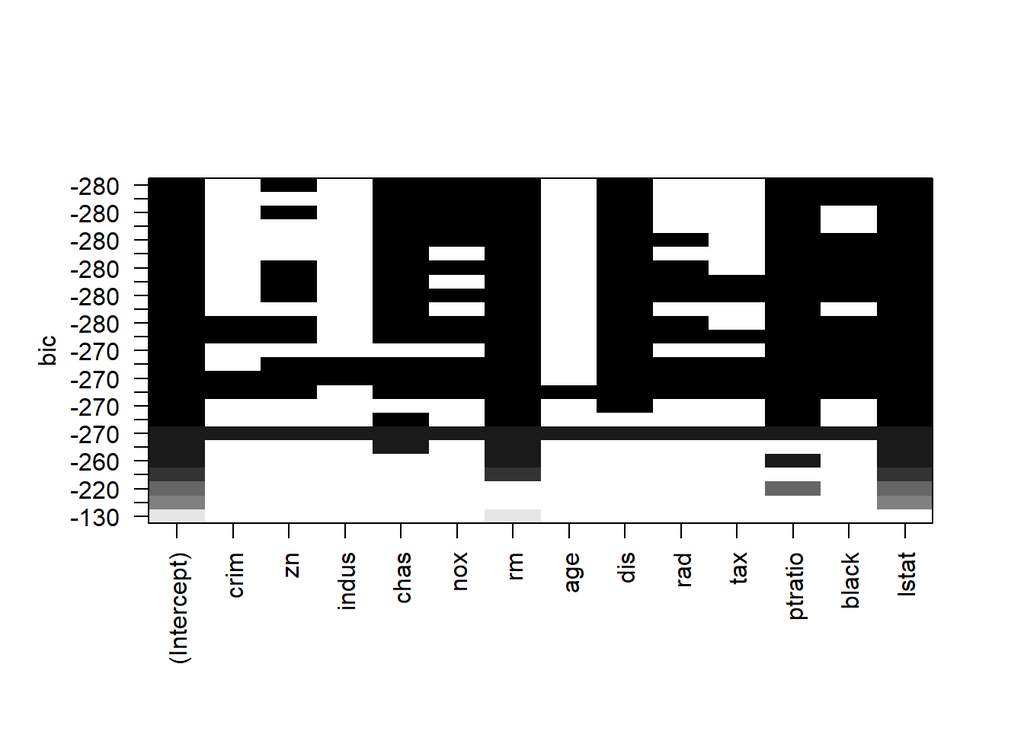

```r
library(leaps)
library(ggplot2)
combinaciones= regsubsets(medv~ ., data = data_boston_sample, nbest = 2, nvmax = 13, method = "exhaustive")
plot(combinaciones)
```

```r
resumen_combinaciones=summary(combinaciones)

#Extraer mejores sub conjuntos
i_bic_minimo=which.min(resumen_combinaciones[["bic"]])
i_r2a_maximo=which.max(resumen_combinaciones[["adjr2"]])

mejor_comb_bic=resumen_combinaciones[["which"]][i_bic_minimo,]
mejor_comb_r2a=resumen_combinaciones[["which"]][i_r2a_maximo,]

# extraer las variables seleccionadas

comb_mejor_bic = names(mejor_comb_bic[mejor_comb_bic == TRUE])
comb_mejor_r2a = names(mejor_comb_r2a[mejor_comb_r2a == TRUE])

#ELIMINAR VAIRABLES INDICADORAS

nombres_mejor_bic= unique(gsub("~(.*)\\d$","\\1",comb_mejor_bic))
nombres_mejor_r2a= unique(gsub("~(.*)\\d$","\\1",comb_mejor_r2a))

#obtener las formulas
pred_mejor_bic=paste(nombres_mejor_bic[-1],collapse=" + ")
pred_mejor_r2a=paste(nombres_mejor_r2a[-1],collapse=" + ")

fmla_mejor_bic=as.formula(paste("medv", pred_mejor_bic,sep = " ~ "))
fmla_mejor_r2a=as.formula(paste("medv", pred_mejor_r2a,sep = " ~ "))

# construir y mostrar
modelo_mejor_bic=lm(fmla_mejor_bic, data = data_boston_sample)
modelo_mejor_r2a=lm(fmla_mejor_r2a, data = data_boston_sample)
cat("Modelo que minimiza el BIC:\n")
```

```
## Modelo que minimiza el BIC:
```

```r
summary(modelo_mejor_bic)
```

```
##
## Call:
## lm(formula = fmla_mejor_bic, data = data_boston_sample)
##
## Residuals:
##     Min      1Q  Median      3Q     Max
## -8.3956 -2.8157 -0.6918  1.7342 25.2142
##
## Coefficients:
##               Estimate Std. Error t value Pr(>|t|)
## (Intercept)  26.722926   6.700889   3.988 8.84e-05 ***
## zn            0.044595   0.017744   2.513 0.012615 *
## chas          4.222761   1.119803   3.771 0.000205 ***
## nox         -11.219059   4.330524  -2.591 0.010162 *
## rm            3.703104   0.539980   6.858 5.84e-11 ***
## dis          -1.395683   0.247393  -5.642 4.71e-08 ***
## ptratio      -0.634093   0.161711  -3.921 0.000115 ***
## black         0.009598   0.003795   2.529 0.012077 *
## lstat        -0.674239   0.062327 -10.818  < 2e-16 ***
## ---
## Signif. codes:  0 '***' 0.001 '**' 0.01 '*' 0.05 '.' 0.1 ' ' 1
##
## Residual standard error: 4.747 on 241 degrees of freedom
## Multiple R-squared:  0.7344, Adjusted R-squared:  0.7256
## F-statistic: 83.29 on 8 and 241 DF,  p-value: < 2.2e-16
```

```r
cat("Modelo que maximiza el R2 ajustado:\n")
```

```
## Modelo que maximiza el R2 ajustado:
```

```r
summary(modelo_mejor_r2a)
```

```
##
## Call:
## lm(formula = fmla_mejor_r2a, data = data_boston_sample)
##
## Residuals:
##     Min      1Q  Median      3Q     Max
## -8.0882 -2.7148 -0.7883  1.5783 23.9870
##
## Coefficients:
##               Estimate Std. Error t value Pr(>|t|)
## (Intercept)  31.752758   6.910166   4.595 7.02e-06 ***
## crim         -0.094228   0.053453  -1.763 0.079215 .
## zn            0.050500   0.018144   2.783 0.005812 **
## chas          3.990060   1.107346   3.603 0.000383 ***
## nox         -11.524867   4.854326  -2.374 0.018384 *
## rm            3.412436   0.539503   6.325 1.24e-09 ***
## dis          -1.431726   0.246581  -5.806 2.03e-08 ***
## rad           0.276813   0.088051   3.144 0.001880 **
## tax          -0.010554   0.004625  -2.282 0.023359 *
## ptratio      -0.709090   0.181572  -3.905 0.000123 ***
## black         0.010049   0.003938   2.552 0.011331 *
## lstat        -0.651035   0.062659 -10.390  < 2e-16 ***
## ---
## Signif. codes:  0 '***' 0.001 '**' 0.01 '*' 0.05 '.' 0.1 ' ' 1
##
## Residual standard error: 4.675 on 238 degrees of freedom
## Multiple R-squared:  0.7456, Adjusted R-squared:  0.7338
## F-statistic: 63.41 on 11 and 238 DF,  p-value: < 2.2e-16
```

en base a lo anterior escogeremos las variables lstat(porcentaje de población con bajo estatus socioeconómico) y rm(número promedio de habitaciones por vivienda) basados en su consistencia en base a la significacncia individual, aparte de ser intiuitivamente variables que pueden influir en el precio de la vivienda.

A continuacion se realizara el modelo y se verificara su confiabilidad y calidad predictiva utilizando validacion cruzada simple

```r
# Construir el modelo de regresión lineal múltiple con las variables lstat y rm
modelo_final <- lm(medv ~ lstat + rm, data = data_boston_sample)
# Resumen del modelo
summary(modelo_final)
```

```
##
## Call:
## lm(formula = medv ~ lstat + rm, data = data_boston_sample)
##
## Residuals:
##    Min     1Q Median     3Q    Max
## -9.463 -3.605 -1.254  1.738 26.757
##
## Coefficients:
##             Estimate Std. Error t value Pr(>|t|)
## (Intercept)  3.27699    4.20077   0.780    0.436
## lstat       -0.70238    0.05826 -12.057  < 2e-16 ***
## rm           4.47808    0.59671   7.505 1.11e-12 ***
## ---
## Signif. codes:  0 '***' 0.001 '**' 0.01 '*' 0.05 '.' 0.1 ' ' 1
##
## Residual standard error: 5.445 on 247 degrees of freedom
## Multiple R-squared:  0.6418, Adjusted R-squared:  0.6389
## F-statistic: 221.2 on 2 and 247 DF,  p-value: < 2.2e-16
```

Por parte de la confiabilidad se debe tener en cuenta 9 condiciones:

1. variables de respuesta continua y cuantitavia: se cumple ya que estamos hablando de dinero
2. predictores cuantitativos o dicotomicos: se cumple ya que lstat y rm son cuantitativos
3. predictores deben poseer algun grado de variabilidad: se cumple ya que lstat y rm tienen variabilidad

```r
var(data_boston_sample$lstat)
```

```
## [1] 51.20505
```

```r
var(data_boston_sample$rm)
```

```
## [1] 0.4880478
```

4. cada predictor debe estar relacionado linealmente
5. la distribucion de los residuos debe ser normal
6. la varianza de los residuos debe ser constante

lo anterior lo verificaremos mirando los graficos de residuos vs valores ajustados y el histograma de los residuos

```r
library(car)
```

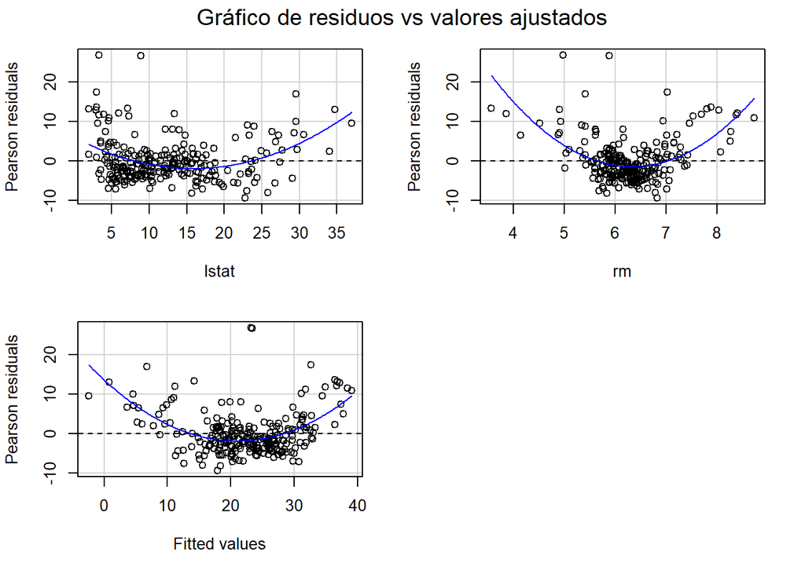

```
##            Test stat Pr(>|Test stat|)
## lstat         6.5093        4.205e-10 ***
## rm           10.7167        < 2.2e-16 ***
## Tukey test   10.4630        < 2.2e-16 ***
## ---
## Signif. codes:  0 '***' 0.001 '**' 0.01 '*' 0.05 '.' 0.1 ' ' 1
```

```r
residualPlots(modelo_final, main = "Gráfico de residuos vs valores ajustados")
```

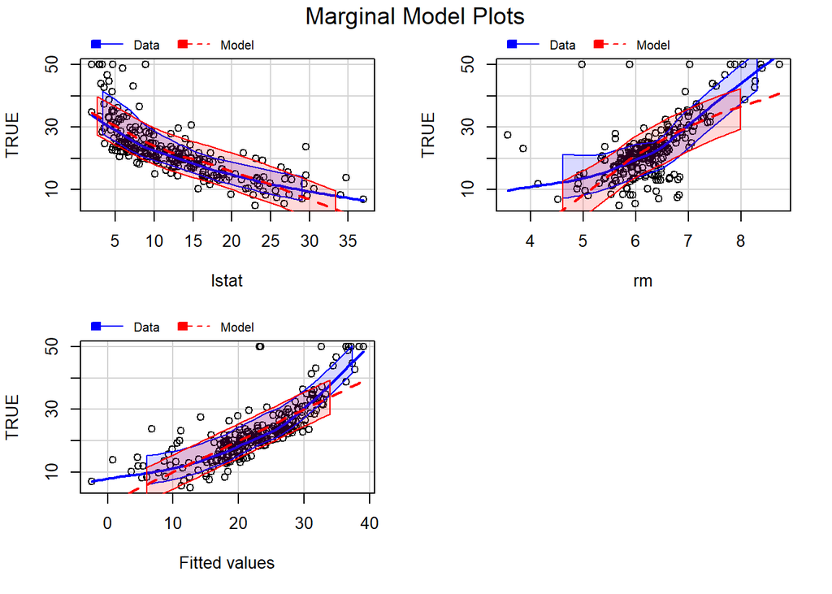

```r
marginalModelPlots(modelo_final,sd=TRUE)
```

```r
ncvTest(modelo_final)
```

```
## Non-constant Variance Score Test
## Variance formula: ~ fitted.values
## Chisquare = 0.1208244, Df = 1, p = 0.72814
```